# ride-sharing

```python
import pandas as pd
import matplotlib as mpl
import matplotlib.pyplot as plt
import seaborn as sns

import plotly.offline as py
import plotly.graph_objs as go
from plotly.offline import iplot
from plotly.graph_objs import Scatter

from scipy import stats as st
import numpy as np

import seaborn as sns
import squarify

import math
import numpy as np
from scipy import stats as st
import numpy as np

pd.options.display.max_columns = None
```

### Step 1. Open the data file and study the general information

## **comment:**

#### Change DF names

```python
df_companies  = pd.read_csv('project_sql_result_01.csv')
df_trips = pd.read_csv('project_sql_result_04.csv')
df_weather = pd.read_csv('project_sql_result_07.csv')
```

```python
df_companies.head()
```

|  | company_name | trips_amount |
| --- | --- | --- |
| 0 | Flash Cab | 19558 |
| 1 | Taxi Affiliation Services | 11422 |
| 2 | Medallion Leasing | 10367 |
| 3 | Yellow Cab | 9888 |
| 4 | Taxi Affiliation Service Yellow | 9299 |

```python
df_companies.describe()
```

|  | trips_amount |
| --- | --- |
| count | 64.000000 |
| mean | 2145.484375 |
| std | 3812.310186 |
| min | 2.000000 |
| 25% | 20.750000 |
| 50% | 178.500000 |
| 75% | 2106.500000 |
| max | 19558.000000 |

```python
df_companies.describe(include = ['object'])
```

|  | company_name |
| --- | --- |
| count | 64 |
| unique | 64 |
| top | 6742 - 83735 Tasha Ride Inc |
| freq | 1 |

```python
df_companies.info()
```

```
<class 'pandas.core.frame.DataFrame'>
RangeIndex: 64 entries, 0 to 63
Data columns (total 2 columns):
 #   Column        Non-Null Count  Dtype
---  ------        --------------  -----
 0   company_name  64 non-null     object
 1   trips_amount  64 non-null     int64
dtypes: int64(1), object(1)
memory usage: 1.1+ KB
```

```python
df_companies.shape
```

```
(64, 2)
```

```python
df_trips.head()
```

|  | dropoff_location_name | average_trips |
| --- | --- | --- |
| 0 | Loop | 10727.466667 |
| 1 | River North | 9523.666667 |
| 2 | Streeterville | 6664.666667 |
| 3 | West Loop | 5163.666667 |
| 4 | O'Hare | 2546.900000 |

```python
df_trips.describe()
```

|  | average_trips |
| --- | --- |
| count | 94.000000 |
| mean | 599.953728 |
| std | 1714.591098 |
| min | 1.800000 |
| 25% | 14.266667 |
| 50% | 52.016667 |
| 75% | 298.858333 |
| max | 10727.466667 |

```python
df_trips.describe(include = ['object'])
```

|  | dropoff_location_name |
| --- | --- |
| count | 94 |
| unique | 94 |
| top | Portage Park |
| freq | 1 |

```python
df_trips.info()
```

```
<class 'pandas.core.frame.DataFrame'>
RangeIndex: 94 entries, 0 to 93
Data columns (total 2 columns):
 #   Column                 Non-Null Count  Dtype
---  ------                 --------------  -----
 0   dropoff_location_name  94 non-null     object
 1   average_trips          94 non-null     float64
dtypes: float64(1), object(1)
memory usage: 1.6+ KB
```

```python
df_trips.shape
```

```
(94, 2)
```

```python
df_weather.head()
```

|  | start_ts | weather_conditions | duration_seconds |
| --- | --- | --- | --- |
| 0 | 2017-11-25 16:00:00 | Good | 2410.0 |
| 1 | 2017-11-25 14:00:00 | Good | 1920.0 |
| 2 | 2017-11-25 12:00:00 | Good | 1543.0 |
| 3 | 2017-11-04 10:00:00 | Good | 2512.0 |
| 4 | 2017-11-11 07:00:00 | Good | 1440.0 |

```python
df_weather.describe()
```

|  | duration_seconds |
| --- | --- |
| count | 1068.000000 |
| mean | 2071.731273 |
| std | 769.461125 |
| min | 0.000000 |
| 25% | 1438.250000 |
| 50% | 1980.000000 |
| 75% | 2580.000000 |
| max | 7440.000000 |

```python
df_weather.describe(include = ['object'])
```

|  | start_ts | weather_conditions |
| --- | --- | --- |
| count | 1068 | 1068 |
| unique | 81 | 2 |
| top | 2017-11-11 10:00:00 | Good |
| freq | 48 | 888 |

```python
df_weather.shape
```

```
(1068, 3)
```

## **comment:**

#### Show entries with duration_seconds is 0

```python
df_weather[df_weather['duration_seconds'] == 0]
```

|  | start_ts | weather_conditions | duration_seconds |
| --- | --- | --- | --- |
| 163 | 2017-11-11 09:00:00 | Good | 0.0 |
| 168 | 2017-11-11 07:00:00 | Good | 0.0 |
| 204 | 2017-11-18 19:00:00 | Good | 0.0 |
| 552 | 2017-11-04 01:00:00 | Good | 0.0 |
| 801 | 2017-11-04 09:00:00 | Good | 0.0 |
| 1063 | 2017-11-25 11:00:00 | Good | 0.0 |

## **comment:**

#### There are 6 such entries, it is less the 1% .

#### change start_ts into datetime

```python
df_weather['start_ts'] = pd.to_datetime(df_weather['start_ts'], format = '%Y-%m-%d %H:%M:%S' )
```

### Step 2. Prepare the data

#### change average_trips to int

```python
df_trips.average_trips = df_trips.average_trips.astype(int)
```

#### change duration_seconds to int

```python
df_weather.duration_seconds = df_weather.duration_seconds.astype(int)
```

### Step 3. Analyze the data

#### identify the top 10 neighborhoods in terms of drop-offs

```python
top_10_drop_offs_df = df_trips.sort_values('average_trips', ascending=False).head(10).reset_index()
```

```python
top_10_drop_offs_df
```

|  | index | dropoff_location_name | average_trips |
| --- | --- | --- | --- |
| 0 | 0 | Loop | 10727 |
| 1 | 1 | River North | 9523 |
| 2 | 2 | Streeterville | 6664 |
| 3 | 3 | West Loop | 5163 |
| 4 | 4 | O'Hare | 2546 |
| 5 | 5 | Lake View | 2420 |
| 6 | 6 | Grant Park | 2068 |
| 7 | 7 | Museum Campus | 1510 |
| 8 | 8 | Gold Coast | 1364 |
| 9 | 9 | Sheffield & DePaul | 1259 |

### make graphs: taxi companies and number of rides, top 10 neighborhoods by number of dropoffs

#### lollypop graphs taxi companies and number of rides

#### There are many small companies with very little impact on the market regarding volume of trips.

#### Will take into account companies with over than 1000 trips.

## **comment:**

#### The Q3 for trips_amount is 2106 . with an STD of 3812 .

#### it would make sense to use that number as a border.

#### But then there will be very few companies left on the list and the visualization of how successful these companies are will be less clear.

#### So I will use border of 1000 for emphasis.

```python
company_over_1000_trips = df_companies[df_companies['trips_amount'] > 1000]
```

```python
company_over_1000_trips.head()
```

|  | company_name | trips_amount |
| --- | --- | --- |
| 0 | Flash Cab | 19558 |
| 1 | Taxi Affiliation Services | 11422 |
| 2 | Medallion Leasing | 10367 |
| 3 | Yellow Cab | 9888 |
| 4 | Taxi Affiliation Service Yellow | 9299 |

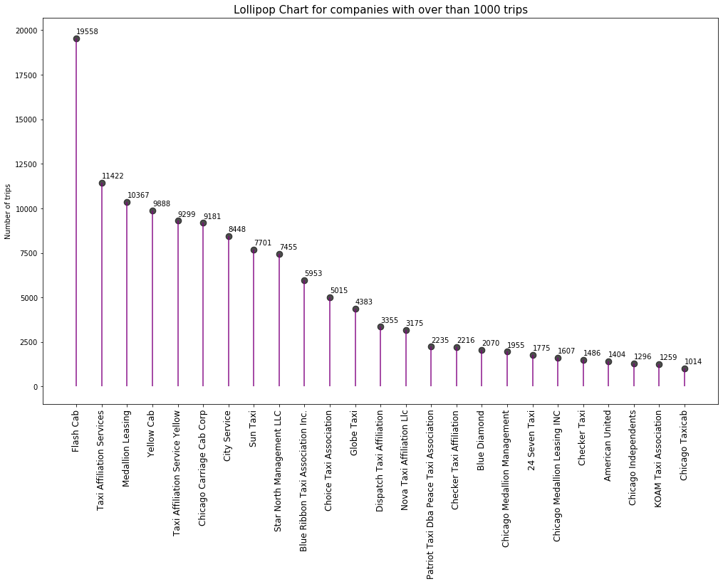

```python
fig, ax = plt.subplots(figsize = (17, 10))
ax.vlines(x = company_over_1000_trips.company_name, ymin = 0, ymax = company_over_1000_trips.trips_amount, color = 'purple', alpha = 0.7, linewidth = 2)
ax.scatter(x = company_over_1000_trips.company_name, y = company_over_1000_trips.trips_amount, s = 75, color = 'black', alpha = 0.7)

#set title
ax.set_title('Lollipop Chart for companies with over than 1000 trips', fontdict = {'size': 15})
#set lable for Y
ax.set_ylabel('Number of trips')
#set ticks
ax.set_xticks(company_over_1000_trips.company_name)
ax.set_xticklabels(company_over_1000_trips.company_name, rotation = 90, fontdict = {'horizontalalignment' : 'center', 'size': 12})

#add text above the dot
for row in company_over_1000_trips.itertuples():
    ax.text(row.company_name, row.trips_amount + 260, s = round(row.trips_amount, 2))
```

#### lollypop graphs top 10 neighborhoods by number of drop-offs

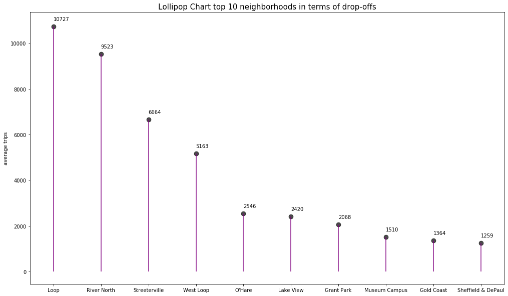

```python
fig, ax = plt.subplots(figsize = (17, 10))
ax.vlines(x = top_10_drop_offs_df.dropoff_location_name, ymin = 0, ymax = top_10_drop_offs_df.average_trips, color = 'purple', alpha = 0.7, linewidth = 2)
ax.scatter(x = top_10_drop_offs_df.dropoff_location_name, y = top_10_drop_offs_df.average_trips, s = 75, color = 'black', alpha = 0.7)

#set title
ax.set_title('Lollipop Chart top 10 neighborhoods in terms of drop-offs', fontdict = {'size': 15})
#set lable for Y
ax.set_ylabel('average trips')

#add text above the dot
for row in top_10_drop_offs_df.itertuples():
    ax.text(row.dropoff_location_name, row.average_trips + 260, s = round(row.average_trips, 2))
```

### draw conclusions based on each graph and explain the results

#### When looking at the leading companies in terms of amount of trips,

#### Flash Cab, have significantly more trips then other companies. With about 19500 trips.

#### The next in line companies are in the area of 10000 trips, about half the volume of Flash Cab. And then the number decline much lower.

#### The leading neighborhoods that trips end at are: Loop & River with about 10000 trips.

#### Then comes Streeterville & West Loop.

#### These are probably neighborhoods with a wealthier population. And will be a good location for a campaign.

## **comment:**

#### The four leading areas for drop-offs are: The Loop and Loop & River North and then Streeterville & West Loop.

#### These are all places with many attractions such as restaurants shops museums and other attractions for tourist and for locals.

### Step 5. Testing hypotheses

```python
#### add a 'day_of_week' columns
```

```python
df_weather['day_of_week'] = df_weather['start_ts'].dt.day_name()
```

```python
#### what days are on the DF ?
```

```python
df_weather['day_of_week'].unique()
```

```
array(['Saturday'], dtype=object)
```

## **comment:**

#### There are only Saturday at the DF

#### sort the DF into two lists. for BAD and GOOD weather

```python
df_weather_good = df_weather[df_weather['weather_conditions'] == 'Good']
```

```python
df_weather_bad =  df_weather[df_weather['weather_conditions'] == 'Bad']
```

#### Get a list a duration time for good and bad weather.

```python
df_weather_good = df_weather_good['duration_seconds'].tolist()
```

```python
df_weather_bad = df_weather_bad ['duration_seconds'].tolist()
```

#### The hypothesis: "The average duration of rides from the Loop to O'Hare International Airport changes on rainy Saturdays."

#### H0 will be that that the average duration will be the same.

#### H1 will be that the average is different.

#### Since trips are from the same neighborhood to the same location, it is very likely that the population is similar.

#### The alpha will be 0.05

```python
alpha = .05
equal_var = True

results = st.ttest_ind(df_weather_bad, df_weather_bad, equal_var  = True)

print('p-value: ', results.pvalue)
if (results.pvalue < alpha):
    print("We reject the null hypothesis")
else:
    print("We can't reject the null hypothesis")
```

```
p-value:  1.0
We can't reject the null hypothesis
```

## **comment:**

#### Chicago is a well-known city that attracts many people for relaxation, good time and for business.

#### I would suggest strengthening the campaign near hotels and airports and the harbor.

#### Persuade restaurants and other attractions to call on our company for their clients.